# Water Quality Analysis | Safe for Human Consumption or Not ?

### 2. Importing data and Initial Lookup at the Data

```python
water = pd.read_csv('Data/water_potability.csv')
water.head()
```

|  | ph | Hardness | Solids | Chloramines | Sulfate | Conductivity | Organic_carbon | Trihalomethanes | Turbidity | Potability |
| --- | --- | --- | --- | --- | --- | --- | --- | --- | --- | --- |
| 0 | NaN | 204.890455 | 20791.318981 | 7.300212 | 368.516441 | 564.308654 | 10.379783 | 86.990970 | 2.963135 | 0 |
| 1 | 3.716080 | 129.422921 | 18630.057858 | 6.635246 | NaN | 592.885359 | 15.180013 | 56.329076 | 4.500656 | 0 |
| 2 | 8.099124 | 224.236259 | 19909.541732 | 9.275884 | NaN | 418.606213 | 16.868637 | 66.420093 | 3.055934 | 0 |
| 3 | 8.316766 | 214.373394 | 22018.417441 | 8.059332 | 356.886136 | 363.266516 | 18.436524 | 100.341674 | 4.628771 | 0 |
| 4 | 9.092223 | 181.101509 | 17978.986339 | 6.546600 | 310.135738 | 398.410813 | 11.558279 | 31.997993 | 4.075075 | 0 |

```python
water.info()
```

```
<class 'pandas.core.frame.DataFrame'>
RangeIndex: 3276 entries, 0 to 3275
Data columns (total 10 columns):
 #   Column           Non-Null Count  Dtype
---  ------           --------------  -----
 0   ph               2785 non-null   float64
 1   Hardness         3276 non-null   float64
 2   Solids           3276 non-null   float64
 3   Chloramines      3276 non-null   float64
 4   Sulfate          2495 non-null   float64
 5   Conductivity     3276 non-null   float64
 6   Organic_carbon   3276 non-null   float64
 7   Trihalomethanes  3114 non-null   float64
 8   Turbidity        3276 non-null   float64
 9   Potability       3276 non-null   int64
dtypes: float64(9), int64(1)
memory usage: 256.1 KB
```

```python
water.describe()
```

|  | ph | Hardness | Solids | Chloramines | Sulfate | Conductivity | Organic_carbon | Trihalomethanes | Turbidity | Potability |
| --- | --- | --- | --- | --- | --- | --- | --- | --- | --- | --- |
| count | 2785.000000 | 3276.000000 | 3276.000000 | 3276.000000 | 2495.000000 | 3276.000000 | 3276.000000 | 3114.000000 | 3276.000000 | 3276.000000 |
| mean | 7.080795 | 196.369496 | 22014.092526 | 7.122277 | 333.775777 | 426.205111 | 14.284970 | 66.396293 | 3.966786 | 0.390110 |
| std | 1.594320 | 32.879761 | 8768.570828 | 1.583085 | 41.416840 | 80.824064 | 3.308162 | 16.175008 | 0.780382 | 0.487849 |
| min | 0.000000 | 47.432000 | 320.942611 | 0.352000 | 129.000000 | 181.483754 | 2.200000 | 0.738000 | 1.450000 | 0.000000 |
| 25% | 6.093092 | 176.850538 | 15666.690297 | 6.127421 | 307.699498 | 365.734414 | 12.065801 | 55.844536 | 3.439711 | 0.000000 |
| 50% | 7.036752 | 196.967627 | 20927.833607 | 7.130299 | 333.073546 | 421.884968 | 14.218338 | 66.622485 | 3.955028 | 0.000000 |
| 75% | 8.062066 | 216.667456 | 27332.762127 | 8.114887 | 359.950170 | 481.792304 | 16.557652 | 77.337473 | 4.500320 | 1.000000 |
| max | 14.000000 | 323.124000 | 61227.196008 | 13.127000 | 481.030642 | 753.342620 | 28.300000 | 124.000000 | 6.739000 | 1.000000 |

### Insight Drawn from head(), info() and describe()

There are total 10 Columns and 3276 Rows in our Data. And all the Columns are Numerical(Potability can also be considered as a binary/boolean type column as we only have 0s and 1s.

From the info() call we can clearly see that the Data has many Null(Nan) values which are displayed below using a Bargraph.

From the describe() call we can get a good look at the Min, Max, Mean, Standard Deviation etc. Also we will be plotting many graphs to draw conclution from the Data.

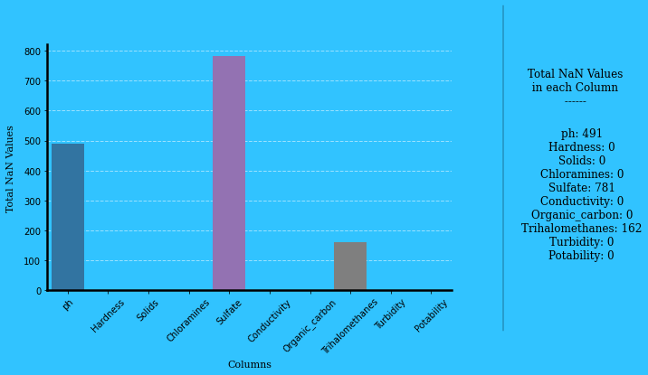

```python
x_data, y_data = [], []

heading_string = '''
                 Total NaN Values
                 in each Column
                 ------
                 '''

content_string = ''''''

for column in water.columns:
    x_data.append(column)
    y_data.append(water[column].isna().sum())
    content_string += f"{column}: {water[column].isna().sum()}\n"

ep = EasyPlot(sn)
fig, axis = ep.descriptive_plot(figsize=(8, 5), draw_line=True)

style_axis = StyleAxis(axis)
style_axis.despine_axis()
style_axis.draw_grid_lines(y_axis_dict={'color': 'white', 'alpha': 0.5})
style_axis.alter_axis_spine(linewidth='2.5')

axis.set_ylabel("Total NaN Values", fontdict=sn.get_font_dict(fontsize=11))
axis.yaxis.set_label_coords(-0.09,0.5)

axis.set_xlabel("Columns", fontdict=sn.get_font_dict(fontsize=11))
axis.xaxis.set_label_coords(0.5,-0.3)

sns.barplot(x=x_data, y=y_data, ax=axis)
plt.xticks(rotation=45)

fig.text(1.08, 0.75, heading_string, fontdict=sn.get_font_dict(fontsize=12))
fig.text(1.15, 0.4, content_string, fontdict=sn.get_font_dict(fontsize=12))

plt.show()
```

### Checking if the Data is Balanced.

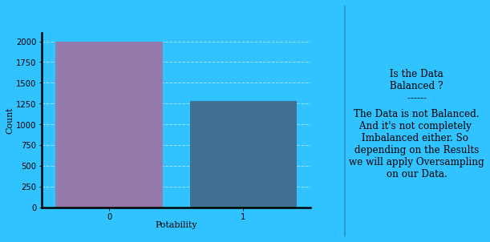

```python
heading_string = '''
                 Is the Data
                 Balanced ?
                 ------
                 '''

content_string = '''
                 The Data is not Balanced.
                 And it's not completely
                 Imbalanced either. So
                 depending on the Results
                 we will apply Oversampling
                 on our Data.
                 '''

fig, axis = ep.descriptive_plot(figsize=(6, 4), draw_line=True)

style_axis = StyleAxis(axis)
style_axis.despine_axis()
style_axis.draw_grid_lines(y_axis_dict={'color': 'white', 'alpha': 0.5})
style_axis.alter_axis_spine(linewidth='2.5')

axis.set_ylabel("Count", fontdict=sn.get_font_dict(fontsize=11))
axis.yaxis.set_label_coords(-0.12,0.5)

axis.set_xlabel("Potability", fontdict=sn.get_font_dict(fontsize=11))
axis.xaxis.set_label_coords(0.5,-0.1)

x_data = water['Potability'].value_counts().index
y_data = water['Potability'].value_counts().values
sns.barplot(x=x_data, y=y_data, ax=axis, palette=['#9372b2', '#3274a1'])

fig.text(1.13, 0.65, heading_string, fontdict=sn.get_font_dict(fontsize=12))
fig.text(1.13, 0.4, content_string, fontdict=sn.get_font_dict(fontsize=12))

plt.show()
```